# Tidybiology Final Project

Kari Strouse

October 21, 2019

## Load libraries

```r
library(tidyverse)
library(tidybiology)
library(ggrepel)
```

## Import data

I first imported the Omim_GeneMap dataset which contains summary information of human disease gene variants from the [OMIM database](https://www.omim.org/). I also imported the chromosome summary dataset from [a Wikipedia entry about the human chromosome](https://en.wikipedia.org/wiki/Human_chromosome).

## Take a `glimpse` into the data in the dataframe

Omim_GeneMap has 16,992 observations with 14 variables.

```
## Observations: 16,992
## Variables: 14
## $ number_chromosome      <chr> "1", "1", "1", "1", "1", "1", "1", "1", "…
## $ genomic_position_start <dbl> 0, 0, 0, 0, 0, 0, 0, 0, 0, 0, 0, 0, 0, 0,…
## $ genomic_position_end   <dbl> 27600000, 27600000, 123400000, 27600000, …
## $ cyto_location          <chr> "1p36", "1p36", "1p", "1p36", "1p36", "1p…
## $ computed_cyto_location <chr> NA, NA, NA, NA, NA, NA, NA, NA, NA, NA, N…
## $ mim_number             <dbl> 607413, 612367, 606788, 605462, 606928, 1…
## $ gene_symbols           <chr> "AD7CNTP", "ALPQTL2", "ANON1", "BCC1", "B…
## $ gene_name              <chr> "Alzheimer disease neuronal thread protei…
## $ approved_symbol        <chr> NA, NA, NA, NA, NA, "CMM", "CCV", NA, "DY…
## $ entrez_gene_id         <dbl> NA, 100196914, 171514, 100307118, 246259,…
## $ ensembl_gene_id        <chr> NA, NA, NA, NA, NA, NA, NA, NA, NA, NA, N…
## $ comments               <chr> NA, "linkage with rs1780324", NA, "associ…
## $ phenotypes             <chr> NA, "{Alkaline phosphatase, plasma level …
## $ mouse_gene_symbol_id   <chr> NA, NA, NA, NA, NA, NA, NA, NA, NA, NA, N…
```

Chromosome has 24 observations (chromosomes), also with 14 variables.

```
## Observations: 24
## Variables: 14
## $ id                     <fct> 1, 2, 3, 4, 5, 6, 7, 8, 9, 10, 11, 12, 13…
## $ length_mm              <dbl> 85, 83, 67, 65, 62, 58, 54, 50, 48, 46, 4…
## $ basepairs              <dbl> 248956422, 242193529, 198295559, 19021455…
## $ variations             <dbl> 12151146, 12945965, 10638715, 10165685, 9…
## $ protein_codinggenes    <int> 2058, 1309, 1078, 752, 876, 1048, 989, 67…
## $ pseudo_genes           <int> 1220, 1023, 763, 727, 721, 801, 885, 613,…
## $ totallongnc_rna        <int> 1200, 1037, 711, 657, 844, 639, 605, 735,…
## $ totalsmallnc_rna       <int> 496, 375, 298, 228, 235, 234, 208, 214, 1…
## $ mi_rna                 <int> 134, 115, 99, 92, 83, 81, 90, 80, 69, 64,…
## $ r_rna                  <int> 66, 40, 29, 24, 25, 26, 24, 28, 19, 32, 2…
## $ sn_rna                 <int> 221, 161, 138, 120, 106, 111, 90, 86, 66,…
## $ sno_rna                <int> 145, 117, 87, 56, 61, 73, 76, 52, 51, 56,…
## $ miscnc_rna             <int> 192, 176, 134, 104, 119, 105, 143, 82, 96…
## $ centromereposition_mbp <dbl> 125.0, 93.3, 91.0, 50.4, 48.4, 61.0, 59.9…
```

## EDA

I wanted to visualize the number of OMIM entries on each chromosome.  
I first cleaned up omim_genemap so that it only included hits that were mapped to a valid chromosome because a few rows contained extraneous information about formatting.

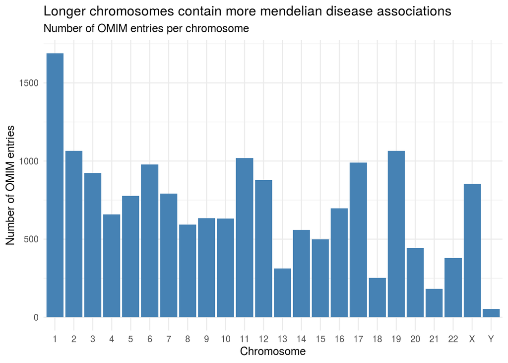

## EDA Graph

I wanted to investigate the relationship between genetic variation and the number of disease associations on a chromosome.

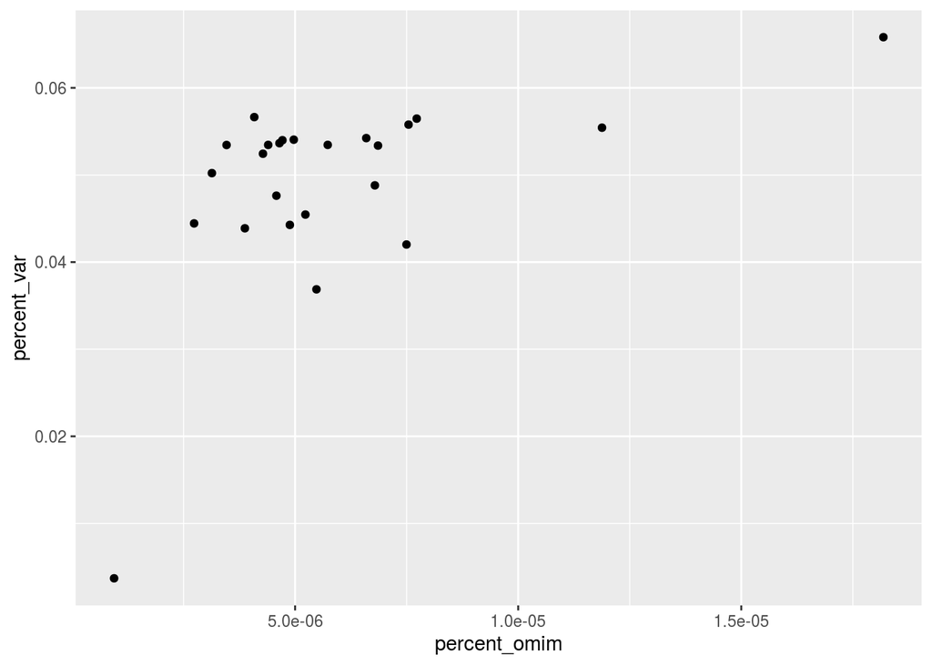

**I see a general trend, but which chromosomes follow this trend more closely than others?**

## Final Graph

Because I was interested in comparing two continuous variables, I chose to stick to a scatterplot and add a linear regression line and data point labels for each chromosome.

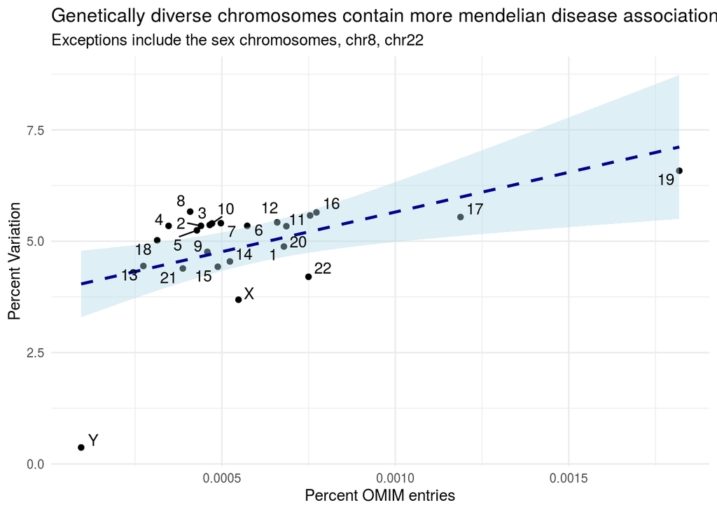

## Conclusions

The amount of genetic variation within a chromosome correlates with the amount of mendelian disease associations it contains. The sex chromosomes and chromosome 22 have contain genetic variation than expected given the number of disease associations they contain.

## Prioritized follow-up studies

Since OMIM only contains disease associations from the coding portion of the genome, I would like to compare the amount of was **protein-coding variation** in each chromosome and the number of mendelian disease associations in OMIM.  
Further, I would like to compare the **total genetic variation** to the number of GWAS hits for common diseases on each chromosome because GWAS results include both coding and non-coding regions.

## Acknolwedgements

Thank you to Dr. Hirschey and our TA’s Allie and Akshay. Shoutout to tidyverse creators for helping to make the world a bit more tidy.